# Appendix S1. Detailed instructions for replicating analyses and reproducing results.

This is version 0.18.01.11.

```
## [1] TRUE
```

## Requirements

All analyses require the [R software](https://cran.r-project.org/) (v3.2.3) for data retrieval, data processing, and summarizing model results, and the [JAGS software](http://mcmc-jags.sourceforge.net/) (v4.2.0) for Markov chain Monte Carlo (MCMC) simulation. Please note that some of the R code below may not work with older versions of JAGS due to some changes in the ways that arrays are handled.

We also need a few packages that are not included with the base installation of R, so we begin by installing them (if necessary) and then loading them.

```r
if(!require("R2jags")) {
  install.packages("R2jags")
  library("R2jags")
}
if(!require("readr")) {
  install.packages("readr")
  library("readr")
}
if(!require("gsl")) {
  install.packages("gsl")
  library("gsl")
}
if(!require("loo")) {
  install.packages("loo")
  library("loo")
}
```

The last thing we’ll need a couple of helper functions.

```r
## better round
Re2prec <- function(x, map = "round", prec = 1) {
  ## 'map' can be round, floor, or ceiling
  ## 'prec' is nearest value (eg, 0.1 means to nearest tenth); default 1 gives normal behavior
  if(prec<=0) { stop("\"prec\" cannot be less than or equal to 0") }
  do.call(map,list(x/prec))*prec
}

## return spring transition index
get_STI <- function(x, day_max = 200) {
    return(min(which(x==min(x[1:day_max]))))
}

## colVars; from Gelman
## returns the column-wise variance of a matrix
colVars <- function(a) {
    n <- dim(a)[[1]]
    c <- dim(a)[[2]]
    mm <- matrix(.colMeans(a, n, c), n, c, byrow = TRUE)
    return(.colMeans(((a - mm) ^ 2), n, c) * n / (n - 1))
}

## waic; from Gelman
## computes WAIC based on pointwise log-like
waic <- function(log_lik) {
  S <- nrow(log_lik)
  n <- ncol(log_lik)
  lpd <- log(colMeans(exp(log_lik)))
  p_waic <- colVars(log_lik)
  elpd_waic <- lpd - p_waic
  waic <- -2*elpd_waic
  loo_weights_raw <- 1/exp(log_lik-max(log_lik))
  loo_weights_normalized <- loo_weights_raw /
    matrix(colMeans(loo_weights_raw),nrow = S,ncol = n,byrow = TRUE)
  loo_weights_regularized <- pmin(loo_weights_normalized, sqrt(S))
  elpd_loo <- log(colMeans(exp(log_lik)*loo_weights_regularized) /
                    colMeans(loo_weights_regularized))
  p_loo <- lpd - elpd_loo
  pointwise <- cbind(waic,lpd,p_waic,elpd_waic,p_loo,elpd_loo)
  total <- colSums(pointwise)
  se <- sqrt(n*colVars(pointwise))
  return(list(waic = total["waic"],
              elpd_waic = total["elpd_waic"],
              p_waic = total["p_waic"],
              elpd_loo = total["elpd_loo"],
              p_loo = total["p_loo"],
              pointwise = pointwise,
              total = total,
              se = se))
}
```

## User inputs

We begin by specifying the names of four necessary data files that contain the following information:

1. observed total number of adult spawners (escapement) by year;
2. observed age composition of adult spawners by year;
3. observed total harvest by year;
4. hatchery releases by year.

Let’s also define the following parameters, which will be referenced throughout the analysis.

- `n_yrs`: number of calendar years of data
- `A`: number of age classes
- `M`: number of covariates

```r
## 1. file with escapement data
## [n_yrs x 2] matrix of obs counts; 1st col is calendar yr
fn_esc <- "skagit_sthd_esc.csv"

## 2. file with age comp data
## [n_yrs x (1+A)]; 1st col is calendar yr
fn_age <- "skagit_sthd_age.csv"
## min & max ages
age_min <- 3
age_max <- 8
## years, if any, of age-comp to skip; see below
age_skip <- 0

## 3. file with harvest data
## [n_yrs x 2] matrix of obs catch; 1st col is calendar yr
fn_harv <- "skagit_sthd_catch.csv"

## 4. file with hatchery release data
## [n_yrs x (1+MM)]; 1st col is calendar yr
fn_hrel <- "skagit_sthd_hrel.csv"

## time lags (years) for covariates
flow_lag <- 1
marine_lag <- 2
hrel_lag <- 2

## number of years of forecasts
n_fore <- 0

## upper threshold for Gelman & Rubin's (1992) potential scale reduction factor (Rhat).
Rhat_thresh <- 1.1

## URL for example data files
## set to NULL if using a local folder/directory
ex_url <- "https://raw.githubusercontent.com/mdscheuerell/skagit_sthd/master/data/"
```

## Loading the fish data

Here we load in the first three data files and do some simple calculations and manipulations. First the spawner data:

```r
## escapement
dat_esc <- read_csv(paste0(ex_url,fn_esc))
## years of data
dat_yrs <- dat_esc$year
## number of years of data
n_yrs <- length(dat_yrs)
## get first & last years
yr_frst <- min(dat_yrs)
yr_last <- max(dat_yrs)
## log of escapement
ln_dat_esc <- c(log(dat_esc$escapement),rep(NA,n_fore))
```

Next the age composition data:

```r
## age comp data
dat_age <- read_csv(paste0(ex_url,fn_age))
## drop year col & first age_min+age_skip rows
dat_age <- dat_age[-(1:(age_min+age_skip)),-1]
## num of age classes
A <- age_max-age_min+1
## add row(s) of NA's for forecast years
if(n_fore > 0) {
  dat_age <- rbind(dat_age,
                   matrix(0, n_fore, A,
                          dimnames = list(n_yrs+seq(n_fore),colnames(dat_age))))
}
## total num of age obs by cal yr
dat_age[,"sum"] <- apply(dat_age, 1, sum)
## row indices for any years with no obs age comp
idx_NA_yrs <- which(dat_age$sum<A, TRUE)
## replace 0's in yrs w/o any obs with NA's
dat_age[idx_NA_yrs,(1:A)] <- NA
## change total in yrs w/o any obs from 0 to A to help dmulti()
dat_age[idx_NA_yrs,"sum"] <- A
## convert class
dat_age <- as.matrix(dat_age)
```

And then the harvest data:

```r
## harvest
dat_harv <- read_csv(paste0(ex_url, fn_harv))
## drop year col & first age_max rows
dat_harv <- c(dat_harv$catch, rep(0,n_fore))
```

## Loading the covariates

### River discharge

```r
## flow site
flow_site <- 12178100
## get URL for flow data from USGS
flow_url <- paste0("https://waterdata.usgs.gov/nwis/dv",
                   "?cb_00060=on",
                   "&format=rdb",
                   "&site_no=",flow_site,
                   "&begin_date=",yr_frst,"-01-01",
                   "&end_date=",yr_last,"-12-31")
```

Next we will retrieve the raw data file and print its metadata.

```r
## raw flow data from USGS
flow_raw <- read_lines(flow_url)
## lines with metadata
hdr_flow <- which(lapply(flow_raw, grep, pattern = "\\#")==1, arr.ind = TRUE)
## print flow metadata
print(flow_raw[hdr_flow], quote = FALSE)
```

```
##  [1] # ---------------------------------- WARNING ----------------------------------------
##  [2] # Some of the data that you have obtained from this U.S. Geological Survey database
##  [3] # may not have received Director's approval. Any such data values are qualified
##  [4] # as provisional and are subject to revision. Provisional data are released on the
##  [5] # condition that neither the USGS nor the United States Government may be held liable
##  [6] # for any damages resulting from its use.
##  [7] #
##  [8] # Additional info: https://help.waterdata.usgs.gov/policies/provisional-data-statement
##  [9] #
## [10] # File-format description:  https://help.waterdata.usgs.gov/faq/about-tab-delimited-output
## [11] # Automated-retrieval info: https://help.waterdata.usgs.gov/faq/automated-retrievals
## [12] #
## [13] # Contact:   gs-w_support_nwisweb@usgs.gov
## [14] # retrieved: 2018-01-11 15:26:12 EST       (vaww02)
## [15] #
## [16] # Data for the following 1 site(s) are contained in this file
## [17] #    USGS 12178100 NEWHALEM CREEK NEAR NEWHALEM, WA
## [18] # -----------------------------------------------------------------------------------
## [19] #
## [20] # Data provided for site 12178100
## [21] #            TS   parameter     statistic     Description
## [22] #        149343       00060     00003     Discharge, cubic feet per second (Mean)
## [23] #
## [24] # Data-value qualification codes included in this output:
## [25] #
## [26] #     A  Approved for publication -- Processing and review completed.
## [27] #     P  Provisional data subject to revision.
## [28] #     e  Value has been estimated.
## [29] #
```

Lastly, we will extract the actual flow data for the years of interest and inspect the file contents.

```r
## flow data for years of interest
dat_flow <-  read_tsv(flow_url, col_names = FALSE, col_types = "ciDdc", skip = max(hdr_flow)+2)
colnames(dat_flow) <- unlist(strsplit(tolower(flow_raw[max(hdr_flow)+1]), split = "\\s+"))
head(dat_flow)
```

```
## # A tibble: 6 x 5
##   agency_cd  site_no   datetime `149343_00060_00003` `149343_00060_00003_cd`
##       <chr>    <int>     <date>                <dbl>                   <chr>
## 1      USGS 12178100 1978-01-01                   58                       A
## 2      USGS 12178100 1978-01-02                   55                       A
## 3      USGS 12178100 1978-01-03                   56                       A
## 4      USGS 12178100 1978-01-04                   66                       A
## 5      USGS 12178100 1978-01-05                   90                       A
## 6      USGS 12178100 1978-01-06                   87                       A
```

The first 3 columns in the data file are the agency (`agency_cd`), location (`site_no`), and date (`datetime`). The daily flow measurements are in the 4th column (`149343_00060_00003`), so we will only keep `datetime` and `149343_00060_00003`, and rename them to `date` and `flow`, respectively. We will also convert the units from “cubic feet per second” to “cubic meters per second”.

```r
## keep only relevant columns
dat_flow <- dat_flow[c("datetime", grep("[0-9]$", colnames(dat_flow), value = TRUE))]
## nicer column names
colnames(dat_flow) <- c("date","flow")
## convert cubic feet to cubic meters
dat_flow$flow <- dat_flow$flow / 35.3147
## flow by year & month
dat_flow$year <- as.integer(format(dat_flow$date,"%Y"))
dat_flow$month <- as.integer(format(dat_flow$date,"%m"))
dat_flow <- dat_flow[,c("year","month","flow")]
```

#### Winter maximum

We are interested in the maximum of the daily peak flows from October through March during the first year that juveniles are rearing in streams. This means we need to combine flow values for the fall of year $t$ with those in the spring of year $t+1$. Therefore, the flow time series will begin in 1978; the last year of flow data will be 2015.

```r
## autumn flows in year t
flow_aut <- subset(dat_flow, (month>=10 & month<=12)
                   & year >= yr_frst & year <= yr_last-age_min+n_fore)
## spring flows in year t+1
flow_spr <- subset(dat_flow, (month>=1 & month<=3)
                   & year >= yr_frst+flow_lag & year <= yr_last-age_min+n_fore+flow_lag)
## change spr year index to match aut
flow_spr[,"year"] <- flow_spr[,"year"] - flow_lag
## combined flows indexed to brood year and calculate max flow over time period
dat_flow_wtr <- aggregate(flow ~ year, data = rbind(flow_aut,flow_spr), max)
dat_flow_wtr[,"flow"] <- round(dat_flow_wtr[,"flow"], 1)
## change year index to brood year
dat_flow_wtr[,"year"] <- dat_flow_wtr[,"year"]
## for plotting purpose later
colnames(dat_flow_wtr)[2] <- "Winter"
```

#### Summer minimum

Now we will calculate the minimum flow juveniles would experience during their first summer (June through September).

```r
## summer flows in year t
flow_sum <- subset(dat_flow, (month>=6 & month<=9)
                   & year >= yr_frst+flow_lag & year <= yr_last-age_min+n_fore+flow_lag)
## change year index to brood year
flow_sum[,"year"] <- flow_sum[,"year"] - flow_lag
## combined flows indexed to brood year and calculate max flow over time period
dat_flow_sum <- aggregate(flow ~ year, data = flow_sum, min)
dat_flow_sum <- round(dat_flow_sum, 2)
## for plotting purpose later
colnames(dat_flow_sum)[2] <- "Summer"
```

### North Pacific Gyre Oscillation

We used the monthly NPGO data provided by Emanuele Di Lorenzo, which are available [here](http://www.o3d.org/npgo/npgo.php). We begin by downloading the raw NPGO data and viewing the metadata.

```r
## URL for NPGO data
url_NPGO <- "http://www.o3d.org/npgo/npgo.php"
## raw NPGO data
NPGO_raw <- read_lines(url_NPGO)
## line with data headers
hdr_NPGO <- which(lapply(NPGO_raw,grep,pattern="YEAR")==1, arr.ind = TRUE)
## print PDO metadata
print(NPGO_raw[seq(hdr_NPGO)],quote = FALSE)
```

```
##  [1]
##  [2] <html>
##  [3] <body>
##  [4]
##  [5] <pre>#  Last update 27-Oct-2017 by E. Di Lorenzo
##  [6] #  NPGO index monthly averages
##  [7] #  from Jan-1950  to  Oct-2017
##  [8] #
##  [9] #  WARNING: Values after Dec-2004 are updated
## [10] #  using Satellite SSHa from AVISO Delayed Time product.
## [11] #  http://opendap.aviso.oceanobs.com/thredds/dodsC/dataset-duacs-dt-global-allsat-msla-h
## [12] #
## [13] #  PRELIMINARY: Values after May-2017 are preliminary and updated
## [14] #  using Satellite SSHa from AVISO Near Real Time product.
## [15] #  http://opendap.aviso.oceanobs.com/thredds/dodsC/dataset-duacs-nrt-over30d-global-allsat-msla-h
## [16] #
## [17] #  The update is performed by taking the NPGO spatial pattern of Di Lorenzo et al. 2008
## [18] #  computed over the period 1950-2004, and projecting the AVISO Satellite SSHa.
## [19] #  During the pre-processing of the AVISO data, we remove the seasonal cycle based on
## [20] #  the 1993-2004 seasonal means.
## [21] #
## [22] #  AVISO PRODUCT UPDATE Summer 2014: AVISO has released a re-processed dataset for the sea level.
## [23] #  Starting from the November 2014, the NPGO index is computed with this updated dataset. NPGO
## [24] #  values from 2004 onward have been recomputed with very minor differences from previous releases.
## [25] #
## [26] #  Ref:
## [27] #  Di Lorenzo et al., 2008: North Pacific Gyre Oscillation
## [28] #  links ocean climate and ecosystem change, GRL.
## [29] #
## [30] #      YEAR            MONTH        NPGO index
```

Next, we will extract the actual NPGO indices for the years of interest and inspect the file contents. We also want the average NPGO annual index from January 1 through December 31 during the first year that the juvenile steelhead are in the ocean (i.e., during their second year of life). Therefore, we need NPGO values from `yr_frst + marine_lag` = 1980 through `yr_last - age_min + n_fore + marine_lag` = 2016.

```r
## NPGO data for years of interest
dat_NPGO <- read_table(url_NPGO, col_names = FALSE,
                       skip = hdr_NPGO + (yr_frst-1950)*12,
                       n_max = (n_yrs-1)*12)
colnames(dat_NPGO) <- c("year","month","NPGO")
## select only years of interest indexed by brood year
dat_NPGO <- dat_NPGO[dat_NPGO$year >= yr_frst+marine_lag &
                     dat_NPGO$year <= yr_last-age_min+n_fore+marine_lag,]
dat_NPGO <- aggregate(dat_NPGO$NPGO, by = list(year = dat_NPGO$year), FUN = mean)
dat_NPGO <- data.frame(year = seq(yr_frst,yr_last-age_min+n_fore), NPGO = dat_NPGO[,2])
dat_NPGO[,"NPGO"] <- round(dat_NPGO[,"NPGO"], 2)
dat_NPGO
```

```
##    year  NPGO
## 1  1978 -0.75
## 2  1979 -0.22
## 3  1980 -0.69
## 4  1981 -0.09
## 5  1982  0.62
## 6  1983 -0.39
## 7  1984 -0.73
## 8  1985  0.43
## 9  1986  1.32
## 10 1987  0.61
## 11 1988 -0.20
## 12 1989 -0.50
## 13 1990 -1.09
## 14 1991 -1.90
```

[output cut: 23 more lines]

### Spring Transition Index

We calculated the spring transition index (STI) from the daily coastal upwelling index (CUI) provided by NOAA’s Pacific Fisheries Environmental Laboratory ([PFEL](https://www.pfeg.noaa.gov/)); you can find more information [here](https://www.pfeg.noaa.gov/products/PFEL/modeled/indices/PFELindices.html). We begin by downloading the raw CUI data and viewing the metadata.

```r
## URL for CUI data
url_CUI <- "https://www.pfeg.noaa.gov/products/PFELData/upwell/daily/p06dayac.all"
## raw CUI data from PFEL
CUI_raw <- read_lines(url_CUI)
## line with data headers
hdr_CUI <- which(lapply(CUI_raw,grep,pattern="YYYYMMDD")==1, arr.ind = TRUE)
## print CUI metadata
print(CUI_raw[seq(hdr_CUI-1)],quote = FALSE)
```

```
## [1] Bakun Index Values from NOAA/NMFS/PFEG for: 48N 125W
## [2] Values are daily average of wind-driven crossshore transports computed from
## [3] FNMOC six-hourly surface pressure analyses.  Indices are in units of cubic
## [4] meters per second along each 100 meters of coastline.  -9999 indicates missing
## [5] value.  Positive numbers indicate offshore transport.  Day is based on PST.
```

```r
## get daily CUI data
dat_CUI <- read_table(url_CUI, col_names = TRUE, skip = hdr_CUI-1)
## extract year from date
dat_CUI$yr <- gsub("[0-9]{4}$","",dat_CUI$YYYYMMDD)
## select only years of interest
cui <- dat_CUI[dat_CUI$yr >= yr_frst+marine_lag & dat_CUI$yr <= yr_last-age_min+n_fore+marine_lag,]
## calculate cumulative upwelling by year
cum_CUI <- tapply(cui$Index, cui$yr, cumsum)
## calc STI for each year
dat_STI <- data.frame(year = seq(yr_frst,yr_last-age_min+n_fore),STI = sapply(cum_CUI,get_STI))
```

### Hatchery releases

The numbers of hatchery fish released each year is listed in a file on the project site. They have already been lagged 2 years (i.e., brood year + 2) to account for the potential competitive interactions during their juvenile life stage. (We will divide the release number by 1000 for plotting purposes.)

```r
dat_hrel <- read_csv(paste0(ex_url,fn_hrel))
dat_hrel <- subset(dat_hrel, dat_hrel$year <= max(dat_STI$year))
dat_hrel[,2] <- dat_hrel[,2]/1000
dat_hrel
```

```
## # A tibble: 37 x 2
##     year    Hrel
##    <int>   <dbl>
##  1  1978 340.416
##  2  1979 274.090
##  3  1980 216.537
##  4  1981 300.942
##  5  1982 241.931
##  6  1983 256.238
##  7  1984 319.220
##  8  1985 125.280
##  9  1986 229.013
## 10  1987 217.948
## # ... with 27 more rows
```

### Combine all covariates

The last thing we will do is combine the covariates into one file and standardize them to have zero-mean and unit-variance.

```r
## covariate(s)
dat_cvrs <- Reduce(function(...) merge(..., all = TRUE),
                   list(dat_flow_sum,dat_NPGO,dat_flow_wtr,dat_STI,dat_hrel))
## drop year col
dat_cvrs <- dat_cvrs[,-1]
#dat_cvrs <- matrix(0, 37, 5)
## transform the covariates to z-scores
scl_cvrs <- as.matrix(scale(dat_cvrs))
## total number of covariates
n_cov <- dim(scl_cvrs)[2]
```

## Specifying models in JAGS

### Ricker with AR(1)

```r
cat("

model {

  ##--------
  ## PRIORS
  ##--------
  ## alpha = exp(a) = intrinsic productivity
  alpha ~ dunif(0.1,20);
  mu_Rkr_a <- log(alpha);
  E_Rkr_a <- mu_Rkr_a + sigma_r/(2 - 2*phi^2);

  ## strength of dens depend
  beta ~ dunif(0,0.01);

  ## AR(1) coef for proc errors
  phi ~ dunif(-0.999,0.999);

  ## process variance for recruits model
  sd_r ~ dunif(0.001,20);
  tau_r <- pow(sd_r,-2);
  sigma_r <- pow(sd_r,2);

  ## innovation in first year
  innov_1 ~ dnorm(0,tau_r*(1-phi*phi));

  ## obs variance for spawners
  sd_s ~ dunif(0.001,20);
  tau_s <- pow(sd_s,-2);
  sigma_s <- pow(sd_s,2);

  ## maturity schedule
  ## unif vec for Dirch prior
  for(i in 1:A) { theta[i] <- 1 }
  ## hyper-mean for maturity
  pi_eta ~ ddirch(theta);
  ## hyper-prec for maturity
  pi_tau ~ dunif(0.01,100);
  for(t in 1:(n_yrs-age_min+n_fore)) { pi_vec[t,1:A] ~ ddirch(pi_eta*pi_tau) }

  ## unprojectable early recruits;
  ## hyper mean across all popns
  Rec_mu ~ dnorm(0,0.001);
  ## hyper SD across all popns
  Rec_sig ~ dunif(0,100);
  ## precision across all popns
  Rec_tau <- pow(Rec_sig,-2);
  ## multipliers for unobservable total runs
  ttl_run_mu ~ dunif(1,5);
  ttl_run_tau ~ dunif(1,20);

  ##------------
  ## LIKELIHOOD
  ##------------
  ## 1st brood yr requires different innovation
  ## predicted recruits in BY t
  ln_Rkr_a[1] <- mu_Rkr_a;
  E_ln_Rec[1] <- ln_Rkr_a[1] + ln_Sp[1] - beta*Sp[1] + phi*innov_1;
  tot_ln_Rec[1] ~ dnorm(E_ln_Rec[1],tau_r);
  res_ln_Rec[1] <- tot_ln_Rec[1] - E_ln_Rec[1];
  ## median of total recruits
  tot_Rec[1] <- exp(tot_ln_Rec[1]);

  ## R/S
  ln_RS[1] <- tot_ln_Rec[1] - ln_Sp[1];

  ## brood-yr recruits by age
  for(a in 1:A) {
    Rec[1,a] <- max(1,tot_Rec[1] * pi_vec[1,a]);
  }

  ## brood years 2:(n_yrs-age_min)
  for(t in 2:(n_yrs-age_min+n_fore)) {
    ## predicted recruits in BY t
    ln_Rkr_a[t] <- mu_Rkr_a;
    E_ln_Rec[t] <- ln_Rkr_a[t] + ln_Sp[t] - beta*Sp[t] + phi*res_ln_Rec[t-1];
    tot_ln_Rec[t] ~ dnorm(E_ln_Rec[t],tau_r);
    res_ln_Rec[t] <- tot_ln_Rec[t] - E_ln_Rec[t];
    ## median of total recruits
    tot_Rec[t] <- exp(tot_ln_Rec[t]);
    ## R/S
    ln_RS[t] <- tot_ln_Rec[t] - ln_Sp[t];
    ## brood-yr recruits by age
    for(a in 1:A) {
      Rec[t,a] <- max(1,tot_Rec[t] * pi_vec[t,a]);
    }
  } ## end t loop over year

  ## get total cal yr returns for first age_min yrs
  for(i in 1:(age_min+age_skip)) {
    ln_tot_Run[i] ~ dnorm(ttl_run_mu*Rec_mu,Rec_tau/ttl_run_tau);
    tot_Run[i] <- exp(ln_tot_Run[i]);
  }

  ## get predicted calendar year returns by age
  ## matrix Run has dim [(n_yrs-age_min) x A]
  ## step 1: incomplete early broods
  ## first cal yr of this grp is first brood yr + age_min + age_skip
  for(i in 1:(age_max-age_min-age_skip)) {
    ## projected recruits
    for(a in 1:(i+age_skip)) {
      Run[i,a] <- Rec[(age_skip+i)-a+1,a];
    }
    ## imputed recruits
    for(a in (i+1+age_skip):A) {
      lnRec[i,a] ~ dnorm(Rec_mu,Rec_tau);
      Run[i,a] <- exp(lnRec[i,a]);
    }
    ## total run size
    tot_Run[i+age_min+age_skip] <- sum(Run[i,1:A]);
    ## predicted age-prop vec for multinom
    for(a in 1:A) {
      age_v[i,a] <- Run[i,a] / tot_Run[i+age_min];
    }
    ## multinomial for age comp
    dat_age[i,1:A] ~ dmulti(age_v[i,1:A],dat_age[i,A+1]);
    lp_age[i] <- logdensity.multi(dat_age[i,1:A],age_v[i,1:A],dat_age[i,A+1]);
  }

  ## step 2: info from complete broods
  ## first cal yr of this grp is first brood yr + age_max
  for(i in (A-age_skip):(n_yrs-age_min-age_skip+n_fore)) {
    for(a in 1:A) {
      Run[i,a] <- Rec[(age_skip+i)-a+1,a];
    }
    ## total run size
    tot_Run[i+age_min+age_skip] <- sum(Run[i,1:A]);
    ## predicted age-prop vec for multinom
    for(a in 1:A) {
      age_v[i,a] <- Run[i,a] / tot_Run[i+age_min];
    }
    ## multinomial for age comp
    dat_age[i,1:A] ~ dmulti(age_v[i,1:A],dat_age[i,A+1]);
    lp_age[i] <- logdensity.multi(dat_age[i,1:A],age_v[i,1:A],dat_age[i,A+1]);
  }

  ## get predicted calendar year spawners
  ## first cal yr is first brood yr
  for(t in 1:(n_yrs+n_fore)) {
    ## obs model for spawners
    Sp[t] <- max(10,tot_Run[t] - dat_harv[t]);
    ln_Sp[t] <- log(Sp[t]);
    ln_dat_esc[t] ~ dnorm(ln_Sp[t], tau_s);
    lp_esc[t] <- logdensity.norm(ln_dat_esc[t],ln_Sp[t], tau_s);
  }

} ## end model description

", file="IPM_RK_AR.txt")
```

### Ricker with covars & AR(1)

```r
cat("

model {

  ##--------
  ## PRIORS
  ##--------
  ## alpha = exp(a) = intrinsic productivity
  alpha ~ dunif(0.1,20);
  mu_Rkr_a <- log(alpha);
  E_Rkr_a <- mu_Rkr_a + sigma_r/(2 - 2*phi^2);

  ## strength of dens depend
  beta ~ dunif(0,0.01);

  ## covariate effects
  # for(i in 1:n_cov) { gamma[i] ~ dnorm(0,0.01) }
  gamma ~ dnorm(0,0.01);

  ## AR(1) coef for proc errors
  phi ~ dunif(-0.999,0.999);

  ## process variance for recruits model
  sd_r ~ dunif(0.001,20);
  tau_r <- pow(sd_r,-2);
  sigma_r <- pow(sd_r,2);

  ## innovation in first year
  innov_1 ~ dnorm(0,tau_r*(1-phi*phi));

  ## obs variance for spawners
  sd_s ~ dunif(0.001,20);
  tau_s <- pow(sd_s,-2);
  sigma_s <- pow(sd_s,2);

  ## maturity schedule
  ## unif vec for Dirch prior
  for(i in 1:A) { theta[i] <- 1 }
  ## hyper-mean for maturity
  pi_eta ~ ddirch(theta);
  ## hyper-prec for maturity
  pi_tau ~ dunif(0.01,100);
  for(t in 1:(n_yrs-age_min+n_fore)) { pi_vec[t,1:A] ~ ddirch(pi_eta*pi_tau) }

  ## unprojectable early recruits;
  ## hyper mean across all popns
  Rec_mu ~ dnorm(0,0.001);
  ## hyper SD across all popns
  Rec_sig ~ dunif(0,100);
  ## precision across all popns
  Rec_tau <- pow(Rec_sig,-2);
  ## multipliers for unobservable total runs
  ttl_run_mu ~ dunif(1,5);
  ttl_run_tau ~ dunif(1,20);

  ##------------
  ## LIKELIHOOD
  ##------------
  ## 1st brood yr requires different innovation
  ## predicted recruits in BY t
  # covar[1] <- inprod(gamma,scl_cvrs[1,]);
  covar[1] <- gamma*mod_cvrs[1];
  ln_Rkr_a[1] <- mu_Rkr_a + covar[1];
  E_ln_Rec[1] <- ln_Rkr_a[1] + ln_Sp[1] - beta*Sp[1] + phi*innov_1;
  tot_ln_Rec[1] ~ dnorm(E_ln_Rec[1],tau_r);
  res_ln_Rec[1] <- tot_ln_Rec[1] - E_ln_Rec[1];
  ## median of total recruits
  tot_Rec[1] <- exp(tot_ln_Rec[1]);

  ## R/S
  ln_RS[1] <- tot_ln_Rec[1] - ln_Sp[1];

  ## brood-yr recruits by age
  for(a in 1:A) {
    Rec[1,a] <- max(1,tot_Rec[1] * pi_vec[1,a]);
  }

  ## brood years 2:(n_yrs-age_min)
  for(t in 2:(n_yrs-age_min+n_fore)) {
    ## predicted recruits in BY t
    # covar[t] <- inprod(gamma, scl_cvrs[t,]);
    covar[t] <- gamma*mod_cvrs[t];
    ln_Rkr_a[t] <- mu_Rkr_a + covar[t];
    E_ln_Rec[t] <- ln_Rkr_a[t] + ln_Sp[t] - beta*Sp[t] + phi*res_ln_Rec[t-1];
    tot_ln_Rec[t] ~ dnorm(E_ln_Rec[t],tau_r);
    res_ln_Rec[t] <- tot_ln_Rec[t] - E_ln_Rec[t];
    ## median of total recruits
    tot_Rec[t] <- exp(tot_ln_Rec[t]);
    ## R/S
    ln_RS[t] <- tot_ln_Rec[t] - ln_Sp[t];
    ## brood-yr recruits by age
    for(a in 1:A) {
      Rec[t,a] <- max(1,tot_Rec[t] * pi_vec[t,a]);
    }
  } ## end t loop over year

  ## get total cal yr returns for first age_min yrs
  for(i in 1:(age_min+age_skip)) {
    ln_tot_Run[i] ~ dnorm(ttl_run_mu*Rec_mu,Rec_tau/ttl_run_tau);
    tot_Run[i] <- exp(ln_tot_Run[i]);
  }

  ## get predicted calendar year returns by age
  ## matrix Run has dim [(n_yrs-age_min) x A]
  ## step 1: incomplete early broods
  ## first cal yr of this grp is first brood yr + age_min + age_skip
  for(i in 1:(age_max-age_min-age_skip)) {
    ## projected recruits
    for(a in 1:(i+age_skip)) {
      Run[i,a] <- Rec[(age_skip+i)-a+1,a];
    }
    ## imputed recruits
    for(a in (i+1+age_skip):A) {
      lnRec[i,a] ~ dnorm(Rec_mu,Rec_tau);
      Run[i,a] <- exp(lnRec[i,a]);
    }
    ## total run size
    tot_Run[i+age_min+age_skip] <- sum(Run[i,1:A]);
    ## predicted age-prop vec for multinom
    for(a in 1:A) {
      age_v[i,a] <- Run[i,a] / tot_Run[i+age_min];
    }
    ## multinomial for age comp
    dat_age[i,1:A] ~ dmulti(age_v[i,1:A],dat_age[i,A+1]);
    lp_age[i] <- logdensity.multi(dat_age[i,1:A],age_v[i,1:A],dat_age[i,A+1]);
  }

  ## step 2: info from complete broods
  ## first cal yr of this grp is first brood yr + age_max
  for(i in (A-age_skip):(n_yrs-age_min-age_skip+n_fore)) {
    for(a in 1:A) {
      Run[i,a] <- Rec[(age_skip+i)-a+1,a];
    }
    ## total run size
    tot_Run[i+age_min+age_skip] <- sum(Run[i,1:A]);
    ## predicted age-prop vec for multinom
    for(a in 1:A) {
      age_v[i,a] <- Run[i,a] / tot_Run[i+age_min];
    }
    ## multinomial for age comp
    dat_age[i,1:A] ~ dmulti(age_v[i,1:A],dat_age[i,A+1]);
    lp_age[i] <- logdensity.multi(dat_age[i,1:A],age_v[i,1:A],dat_age[i,A+1]);
  }

  ## get predicted calendar year spawners
  ## first cal yr is first brood yr
  for(t in 1:(n_yrs+n_fore)) {
    ## obs model for spawners
    Sp[t] <- max(1,tot_Run[t] - dat_harv[t]);
    ln_Sp[t] <- log(Sp[t]);
    ln_dat_esc[t] ~ dnorm(ln_Sp[t], tau_s);
    lp_esc[t] <- logdensity.norm(ln_dat_esc[t],ln_Sp[t], tau_s);
  }

} ## end model description

", file="IPM_RK_cov_AR.txt")
```

### Beverton-Holt with AR(1)

```r
cat("

model {

  ##--------
  ## PRIORS
  ##--------
  ## alpha = exp(a) = intrinsic productivity
  alpha ~ dunif(0.1,100);
  mu_BH_a <- log(alpha);
  E_BH_a <- mu_BH_a + sigma_r/(2 - 2*phi^2);

  ## strength of dens depend
  beta ~ dunif(0,0.01);

  ## AR(1) coef for proc errors
  phi ~ dunif(-0.999,0.999);

  ## process variance for recruits model
  sd_r ~ dunif(0.001,20);
  tau_r <- pow(sd_r,-2);
  sigma_r <- pow(sd_r,2);

  ## innovation in first year
  innov_1 ~ dnorm(0,tau_r*(1-phi*phi));

  ## obs variance for spawners
  sd_s ~ dunif(0.001,20);
  tau_s <- pow(sd_s,-2);
  sigma_s <- pow(sd_s,2);

  ## unprojectable early recruits;
  ## hyper mean across all popns
  Rec_mu ~ dnorm(0,0.001);
  ## hyper SD across all popns
  Rec_sig ~ dunif(0,100);
  ## precision across all popns
  Rec_tau <- pow(Rec_sig,-2);
  ## multipliers for unobservable total runs
  ttl_run_mu ~ dunif(1,5);
  ttl_run_tau ~ dunif(1,20);

  ## maturity schedule
  ## unif vec for Dirch prior
  for(i in 1:A) { theta[i] <- 1 }
  ## hyper-mean for maturity
  pi_eta ~ ddirch(theta);
  ## hyper-prec for maturity
  pi_tau ~ dunif(0.01,100);
  for(t in 1:(n_yrs-age_min+n_fore)) { pi_vec[t,1:A] ~ ddirch(pi_eta*pi_tau) }

  ##------------
  ## LIKELIHOOD
  ##------------
  ## 1st brood yr requires different innovation
  ## predicted recruits in BY t
  ln_BH_a[1] <- mu_BH_a;
  E_ln_Rec[1] <- ln_BH_a[1] + ln_Sp[1] - log(1 + beta*Sp[1]) + phi*innov_1;
  tot_ln_Rec[1] ~ dnorm(E_ln_Rec[1],tau_r);
  res_ln_Rec[1] <- tot_ln_Rec[1] - E_ln_Rec[1];
  ## median of total recruits
  tot_Rec[1] <- exp(tot_ln_Rec[1]);

  ## R/S
  ln_RS[1] <- tot_ln_Rec[1] - ln_Sp[1];

  ## brood-yr recruits by age
  for(a in 1:A) {
    Rec[1,a] <- max(1,tot_Rec[1] * pi_vec[1,a]);
  }

  ## brood years 2:(n_yrs-age_min)
  for(t in 2:(n_yrs-age_min+n_fore)) {
    ## predicted recruits in BY t
    ln_BH_a[t] <- mu_BH_a;
    E_ln_Rec[t] <- ln_BH_a[t] + ln_Sp[t] - log(1 + beta*Sp[t]) + phi*res_ln_Rec[t-1];
    tot_ln_Rec[t] ~ dnorm(E_ln_Rec[t],tau_r);
    res_ln_Rec[t] <- tot_ln_Rec[t] - E_ln_Rec[t];
    ## median of total recruits
    tot_Rec[t] <- exp(tot_ln_Rec[t]);
    ## R/S
    ln_RS[t] <- tot_ln_Rec[t] - ln_Sp[t];
    ## brood-yr recruits by age
    for(a in 1:A) {
      Rec[t,a] <- max(1,tot_Rec[t] * pi_vec[t,a]);
    }
  } ## end t loop over year

  ## get total cal yr returns for first age_min yrs
  for(i in 1:(age_min+age_skip)) {
    ln_tot_Run[i] ~ dnorm(ttl_run_mu*Rec_mu,Rec_tau/ttl_run_tau);
    tot_Run[i] <- exp(ln_tot_Run[i]);
  }

  ## get predicted calendar year returns by age
  ## matrix Run has dim [(n_yrs-age_min) x A]
  ## step 1: incomplete early broods
  ## first cal yr of this grp is first brood yr + age_min + age_skip
  for(i in 1:(age_max-age_min-age_skip)) {
    ## projected recruits
    for(a in 1:(i+age_skip)) {
      Run[i,a] <- Rec[(age_skip+i)-a+1,a];
    }
    ## imputed recruits
    for(a in (i+1+age_skip):A) {
      lnRec[i,a] ~ dnorm(Rec_mu,Rec_tau);
      Run[i,a] <- exp(lnRec[i,a]);
    }
    ## total run size
    tot_Run[i+age_min+age_skip] <- sum(Run[i,1:A]);
    ## predicted age-prop vec for multinom
    for(a in 1:A) {
      age_v[i,a] <- Run[i,a] / tot_Run[i+age_min];
    }
    ## multinomial for age comp
    dat_age[i,1:A] ~ dmulti(age_v[i,1:A],dat_age[i,A+1]);
    lp_age[i] <- logdensity.multi(dat_age[i,1:A],age_v[i,1:A],dat_age[i,A+1]);
  }

  ## step 2: info from complete broods
  ## first cal yr of this grp is first brood yr + age_max
  for(i in (A-age_skip):(n_yrs-age_min-age_skip+n_fore)) {
    for(a in 1:A) {
      Run[i,a] <- Rec[(age_skip+i)-a+1,a];
    }
    ## total run size
    tot_Run[i+age_min+age_skip] <- sum(Run[i,1:A]);
    ## predicted age-prop vec for multinom
    for(a in 1:A) {
      age_v[i,a] <- Run[i,a] / tot_Run[i+age_min];
    }
    ## multinomial for age comp
    dat_age[i,1:A] ~ dmulti(age_v[i,1:A],dat_age[i,A+1]);
    lp_age[i] <- logdensity.multi(dat_age[i,1:A],age_v[i,1:A],dat_age[i,A+1]);
  }

  ## get predicted calendar year spawners
  ## first cal yr is first brood yr
  for(t in 1:(n_yrs+n_fore)) {
    ## obs model for spawners
    Sp[t] <- max(10,tot_Run[t] - dat_harv[t]);
    ln_Sp[t] <- log(Sp[t]);
    ln_dat_esc[t] ~ dnorm(ln_Sp[t], tau_s);
    lp_esc[t] <- logdensity.norm(ln_dat_esc[t],ln_Sp[t], tau_s);
  }

} ## end model description

", file="IPM_BH_AR.txt")
```

### Beverton-Holt with covars & AR(1)

```r
cat("

model {

  ##--------
  ## PRIORS
  ##--------
  ## alpha = exp(a) = intrinsic productivity
  alpha ~ dunif(0.1,100);
  mu_BH_a <- log(alpha);
  E_BH_a <- mu_BH_a + sigma_r/2;

  ## strength of dens depend
  beta ~ dunif(0,0.01);

  ## covariate effects
  # for(i in 1:n_cov) { gamma[i] ~ dnorm(0,0.01) }
  gamma ~ dnorm(0,0.01);

  ## AR(1) coef for proc errors
  phi ~ dunif(-0.999,0.999);

  ## innovation in first year
  innov_1 ~ dnorm(0,tau_r*(1-phi*phi));

  ## process variance for recruits model
  sd_r ~ dunif(0.001,20);
  tau_r <- pow(sd_r,-2);
  sigma_r <- pow(sd_r,2);

  ## obs variance for spawners
  sd_s ~ dunif(0.001,20);
  tau_s <- pow(sd_s,-2);
  sigma_s <- pow(sd_s,2);

  ## unprojectable early recruits;
  ## hyper mean across all popns
  Rec_mu ~ dnorm(0,0.001);
  ## hyper SD across all popns
  Rec_sig ~ dunif(0,100);
  ## precision across all popns
  Rec_tau <- pow(Rec_sig,-2);
  ## multipliers for unobservable total runs
  ttl_run_mu ~ dunif(1,5);
  ttl_run_tau ~ dunif(1,20);

  ## maturity schedule
  ## unif vec for Dirch prior
  for(i in 1:A) { theta[i] <- 1 }
  ## hyper-mean for maturity
  pi_eta ~ ddirch(theta);
  ## hyper-prec for maturity
  pi_tau ~ dunif(0.01,100);
  for(t in 1:(n_yrs-age_min+n_fore)) { pi_vec[t,1:A] ~ ddirch(pi_eta*pi_tau) }

  ##------------
  ## LIKELIHOOD
  ##------------
  ## predicted recruits in BY t
  # covar[1] <- inprod(gamma,scl_cvrs[1,]);
  covar[1] <- gamma*mod_cvrs[1];
  ln_BH_a[1] <- mu_BH_a + covar[1];
  E_ln_Rec[1] <- ln_BH_a[1] + ln_Sp[1] - log(1 + beta*Sp[1]) + phi*innov_1;
  tot_ln_Rec[1] ~ dnorm(E_ln_Rec[1],tau_r);
  res_ln_Rec[1] <- tot_ln_Rec[1] - E_ln_Rec[1];
  ## median of total recruits
  tot_Rec[1] <- exp(tot_ln_Rec[1]);

  ## R/S
  ln_RS[1] <- tot_ln_Rec[1] - ln_Sp[1];

  ## brood-yr recruits by age
  for(a in 1:A) {
    Rec[1,a] <- max(1,tot_Rec[1] * pi_vec[1,a]);
  }

  ## brood years 2:(n_yrs-age_min)
  for(t in 2:(n_yrs-age_min+n_fore)) {
    ## predicted recruits in BY t
    # covar[t] <- inprod(gamma, scl_cvrs[t,]);
    covar[t] <- gamma*mod_cvrs[t];
    ln_BH_a[t] <- mu_BH_a + covar[t];
    E_ln_Rec[t] <- ln_BH_a[t] + ln_Sp[t] - log(1 + beta*Sp[t]) + phi*res_ln_Rec[t-1];
    tot_ln_Rec[t] ~ dnorm(E_ln_Rec[t],tau_r);
    res_ln_Rec[t] <- tot_ln_Rec[t] - E_ln_Rec[t];
    ## median of total recruits
    tot_Rec[t] <- exp(tot_ln_Rec[t]);
    ## R/S
    ln_RS[t] <- tot_ln_Rec[t] - ln_Sp[t];
    ## brood-yr recruits by age
    for(a in 1:A) {
      Rec[t,a] <- max(1,tot_Rec[t] * pi_vec[t,a]);
    }
  } ## end t loop over year

  ## get total cal yr returns for first age_min yrs
  for(i in 1:(age_min+age_skip)) {
    ln_tot_Run[i] ~ dnorm(ttl_run_mu*Rec_mu,Rec_tau/ttl_run_tau);
    tot_Run[i] <- exp(ln_tot_Run[i]);
  }

  ## get predicted calendar year returns by age
  ## matrix Run has dim [(n_yrs-age_min) x A]
  ## step 1: incomplete early broods
  ## first cal yr of this grp is first brood yr + age_min + age_skip
  for(i in 1:(age_max-age_min-age_skip)) {
    ## projected recruits
    for(a in 1:(i+age_skip)) {
      Run[i,a] <- Rec[(age_skip+i)-a+1,a];
    }
    ## imputed recruits
    for(a in (i+1+age_skip):A) {
      lnRec[i,a] ~ dnorm(Rec_mu,Rec_tau);
      Run[i,a] <- exp(lnRec[i,a]);
    }
    ## total run size
    tot_Run[i+age_min+age_skip] <- sum(Run[i,1:A]);
    ## predicted age-prop vec for multinom
    for(a in 1:A) {
      age_v[i,a] <- Run[i,a] / tot_Run[i+age_min];
    }
    ## multinomial for age comp
    dat_age[i,1:A] ~ dmulti(age_v[i,1:A],dat_age[i,A+1]);
    lp_age[i] <- logdensity.multi(dat_age[i,1:A],age_v[i,1:A],dat_age[i,A+1]);
  }

  ## step 2: info from complete broods
  ## first cal yr of this grp is first brood yr + age_max
  for(i in (A-age_skip):(n_yrs-age_min-age_skip+n_fore)) {
    for(a in 1:A) {
      Run[i,a] <- Rec[(age_skip+i)-a+1,a];
    }
    ## total run size
    tot_Run[i+age_min+age_skip] <- sum(Run[i,1:A]);
    ## predicted age-prop vec for multinom
    for(a in 1:A) {
      age_v[i,a] <- Run[i,a] / tot_Run[i+age_min];
    }
    ## multinomial for age comp
    dat_age[i,1:A] ~ dmulti(age_v[i,1:A],dat_age[i,A+1]);
    lp_age[i] <- logdensity.multi(dat_age[i,1:A],age_v[i,1:A],dat_age[i,A+1]);
  }

  ## get predicted calendar year spawners
  ## first cal yr is first brood yr
  for(t in 1:(n_yrs+n_fore)) {
    ## obs model for spawners
    Sp[t] <- max(10,tot_Run[t] - dat_harv[t]);
    ln_Sp[t] <- log(Sp[t]);
    ln_dat_esc[t] ~ dnorm(ln_Sp[t], tau_s);
    lp_esc[t] <- logdensity.norm(ln_dat_esc[t],ln_Sp[t], tau_s);
  }

} ## end model description

", file="IPM_BH_cov_AR.txt")
```

## Fitting the models

The last thing we need to do before fitting the model in JAGS is to specify:

1. the data and indices that go into the model;
2. the model parameters and states that we want JAGS to return;
3. the MCMC control parameters.

```r
## 1. data to pass to JAGS
dat_jags <- c("ln_dat_esc", "dat_age", "dat_harv",
              "A", "age_min", "age_max", "age_skip",
              "n_yrs", "n_fore")

## 2. model params/states for JAGS to return
par_jags <- c("lp_age","lp_esc")

## 3. MCMC control params
## MCMC parameters
mcmc_chains <- 4
mcmc_length <- 3e5
mcmc_burn <- 5e4
mcmc_thin <- 200
## total number of MCMC samples
mcmc_samp <- (mcmc_length-mcmc_burn)*mcmc_chains/mcmc_thin
```

### Models without covariates

Please note that the following code takes ~20 min to run on a quad-core machine with 3.5 GHz Intel processors.

```r
## function to create JAGS inits
## Eqn 2
init_vals_AR <- function() {
    list(alpha = 2.0,
         beta = 1/exp(mean(ln_dat_esc, na.rm = TRUE)),
         pi_tau = 1,
         pi_eta = rep(1,A),
         pi_vec = matrix(c(0.02,0.3,0.48,0.15,0.04,0.01), n_yrs-age_min+n_fore, A,
                         byrow = TRUE),
         Rec_mu = log(1000),
         Rec_sig = 0.1,
         tot_ln_Rec = rep(log(1000), n_yrs - age_min + n_fore),
         innov_1 = 0,
         phi = 0.5)
}

## empty list for fits
mod_fits <- vector("list", 2*(1+n_cov))

## list of model info for JAGS
mod_jags <- list(data = dat_jags,
                 parameters.to.save = par_jags,
                 n.chains = as.integer(mcmc_chains),
                 n.iter = as.integer(mcmc_length),
                 n.burnin = as.integer(mcmc_burn),
                 n.thin = as.integer(mcmc_thin))

## fit AR(1) models
mod_jags$inits <- init_vals_AR
## Ricker
mod_jags$model.file <- "IPM_RK_AR.txt"
mod_fits[[1]] <- do.call(jags.parallel, mod_jags)
## B-H
mod_jags$model.file <- "IPM_BH_AR.txt"
mod_fits[[2]] <- do.call(jags.parallel, mod_jags)
```

### Models with 1 covariate

```r
## 1. data to pass to JAGS
dat_jags <- c("dat_age","ln_dat_esc","dat_harv","mod_cvrs",
              "A","age_min","age_max","age_skip",
              "n_yrs","n_fore")
mod_jags$data <- dat_jags

## 2. model params/states for JAGS to return
par_jags <- c("gamma","lp_age","lp_esc")
mod_jags$parameters.to.save <- par_jags

## function to create JAGS inits
## Eqn 4
init_vals_cov_AR <- function() {
    list(alpha = 1,
         beta = 1/exp(mean(ln_dat_esc, na.rm = TRUE)),
         gamma = 1,
         pi_tau = 1,
         pi_eta = rep(1,A),
         pi_vec = matrix(c(0.02,0.3,0.48,0.15,0.04,0.01), n_yrs-age_min+n_fore, A,
                         byrow = TRUE),
         Rec_mu = log(1000),
         Rec_sig = 0.1,
         tot_ln_Rec = rep(log(1000), n_yrs - age_min + n_fore),
         innov_1 = 0,
         phi = 0.5)
}

## fit models with covars
cnt <- 3
for(i in 1:n_cov) {
  ## get covar of interest
  mod_cvrs <- scl_cvrs[, i]
  ## cnt & time stamp
  cat("Count = ", cnt, "; Time = ", round(((proc.time()-timer_start)/60)["elapsed"], 1), "\n",
      file = "cnt_time.txt", append = TRUE, sep = "")
  ## Ricker with cov
  mod_jags$model.file <- "IPM_RK_cov_AR.txt"
  mod_jags$inits <- init_vals_cov_AR
  mod_fits[[cnt]] <- do.call(jags.parallel, mod_jags)
  cnt <- cnt + 1
  ## B-H with cov
  mod_jags$model.file <- "IPM_BH_cov_AR.txt"
  mod_jags$inits <- NULL
  mod_fits[[cnt]] <- do.call(jags.parallel, mod_jags)
  cnt <- cnt + 1
}
```

## Finding the best model

We use Leave-one-out cross-validation (LOO) for estimating pointwise out-of-sample prediction accuracy for each of the models. As with other information criteria, models with lower LOO are considered more robust.

```r
n_mods <- length(mod_fits)
LOO <- vector("numeric",n_mods)
cc_smry_1 <- matrix(NA,n_mods,3)
colnames(cc_smry_1) <- c("lo","med","up")
## extract log densities from JAGS objects
for(i in 1:n_mods) {
  ldens <- cbind(mod_fits[[i]]$BUGSoutput$sims.list$lp_age,
                 mod_fits[[i]]$BUGSoutput$sims.list$lp_esc)
  LOO[i] <- -2*waic(ldens)$elpd_loo
  if(i < 3) {
    cc_smry_1[i,] <- rep(NA,3)
  } else {
    cc_smry_1[i,] <- mod_fits[[i]]$BUGSoutput$summary["gamma", c("2.5%","50%","97.5%")]
  }
}
d_LOO <- round(LOO-min(LOO),1)
wt_LOO <- exp(-0.5*LOO)/sum(exp(-0.5*LOO))
tbl_LOO <- data.frame(errors = c(2,2,rep(c(4,4),n_cov)),
                      model = rep(c("Ricker","B-H"),n_mods/2),
                      covar = c(c(NA,NA),rep(colnames(scl_cvrs),ea = 2)),
                      LOO = round(LOO,1),
                      d_LOO = d_LOO,
                      wt_LOO = round(wt_LOO,3),
                      round(cc_smry_1,2))
# write.csv(tbl_LOO,  row.names = FALSE,
#           file = "Willamette_Chin_SR_flow_models_mainstem_model_selection_all.csv")
best_idx <- which(tbl_LOO$d_LOO==0)
# tbl_LOO[,!(names(tbl_LOO) %in% c("lag","WAIC"))]
tbl_LOO[order(tbl_LOO$LOO),]
```

```
##    errors  model  covar   LOO d_LOO wt_LOO    lo   med   up
## 10      4    B-H    STI 697.0   0.0  0.515 -0.16 -0.03 0.10
## 8       4    B-H Winter 698.2   1.1  0.294 -0.22 -0.08 0.06
## 4       4    B-H Summer 700.7   3.7  0.082 -0.09  0.04 0.18
## 12      4    B-H   Hrel 701.5   4.5  0.055 -0.31 -0.13 0.06
## 2       2    B-H   <NA> 701.7   4.7  0.050    NA    NA   NA
## 3       4 Ricker Summer 707.1  10.1  0.003 -0.09  0.04 0.18
## 6       4    B-H   NPGO 796.5  99.5  0.000 -0.04  0.15 0.54
## 5       4 Ricker   NPGO 838.0 141.0  0.000 -0.33  0.15 0.45
## 7       4 Ricker Winter 873.4 176.4  0.000 -0.27 -0.07 0.47
## 9       4 Ricker    STI 875.1 178.1  0.000 -2.01 -0.03 1.64
## 11      4 Ricker   Hrel 875.8 178.8  0.000 -1.16 -0.17 0.11
## 1       2 Ricker   <NA> 924.5 227.5  0.000    NA    NA   NA
```

WAIC/LOO using `loo` package.

```r
n_mods <- length(mod_fits)
LOO <- vector("numeric",n_mods)
cc_smry_1 <- matrix(NA,n_mods,3)
colnames(cc_smry_1) <- c("lo","med","up")
## extract log densities from JAGS objects
for(i in 1:n_mods) {
  ldens <- cbind(mod_fits[[i]]$BUGSoutput$sims.list$lp_age,
                 mod_fits[[i]]$BUGSoutput$sims.list$lp_esc)
  LOO[i] <- loo(ldens)$looic
  if(i < 3) {
    cc_smry_1[i,] <- rep(NA,3)
  } else {
    cc_smry_1[i,] <- mod_fits[[i]]$BUGSoutput$summary["gamma", c("2.5%","50%","97.5%")]
  }
}
d_LOO <- round(LOO-min(LOO),1)
wt_LOO <- exp(-0.5*LOO)/sum(exp(-0.5*LOO))
tbl_LOO_2 <- data.frame(errors = c(2,2,rep(c(4,4),n_cov)),
                        model = rep(c("Ricker","B-H"),n_mods/2),
                        covar = c(c(NA,NA),rep(colnames(scl_cvrs),ea = 2)),
                        LOO = round(LOO,1),
                        d_LOO = d_LOO,
                        wt_LOO = round(wt_LOO,3),
                        round(cc_smry_1,2))
# write.csv(tbl_LOO,  row.names = FALSE,
#           file = "Willamette_Chin_SR_flow_models_mainstem_model_selection_all.csv")
# best_idx <- which(tbl_LOO_2$d_WAIC==0)
# tbl_LOO[,!(names(tbl_LOO) %in% c("lag","WAIC"))]
tbl_LOO_2[order(tbl_LOO_2$LOO),]
```

```
##    errors  model  covar   LOO d_LOO wt_LOO    lo   med   up
## 10      4    B-H    STI 725.7   0.0  0.740 -0.16 -0.03 0.10
## 4       4    B-H Summer 729.9   4.2  0.091 -0.09  0.04 0.18
## 8       4    B-H Winter 729.9   4.2  0.090 -0.22 -0.08 0.06
## 2       2    B-H   <NA> 730.7   5.1  0.059    NA    NA   NA
## 12      4    B-H   Hrel 732.9   7.2  0.020 -0.31 -0.13 0.06
## 3       4 Ricker Summer 739.6  14.0  0.001 -0.09  0.04 0.18
## 5       4 Ricker   NPGO 861.2 135.5  0.000 -0.33  0.15 0.45
## 7       4 Ricker Winter 901.5 175.9  0.000 -0.27 -0.07 0.47
## 11      4 Ricker   Hrel 905.1 179.4  0.000 -1.16 -0.17 0.11
## 6       4    B-H   NPGO 946.7 221.0  0.000 -0.04  0.15 0.54
## 1       2 Ricker   <NA> 964.3 238.7  0.000    NA    NA   NA
## 9       4 Ricker    STI 979.7 254.1  0.000 -2.01 -0.03 1.64
```

## Refit best model

Now we’ll refit the best model and save all of the parameters/states of interest.

```r
mod_cvrs <- scl_cvrs[,tbl_LOO[best_idx,"covar"]]
mod_jags$parameters.to.save <- c("alpha","E_BH_a","ln_BH_a",
                                 "beta",
                                 "gamma",
                                 "lp_age","lp_esc",
                                 "Sp","Rec","tot_ln_Rec","ln_RS",
                                 "pi_vec",
                                 "sigma_r","sigma_s","res_ln_Rec")
mod_jags$inits <- init_vals_cov_AR
mod_jags$model.file <- "IPM_BH_cov_AR.txt"
best_fit <- do.call(jags.parallel, mod_jags)
```

## Model diagnostics

Here is a histogram of the Gelman & Rubin statistics $(R_{hat})$ for the estimated parameters. Recall that we set an upper threshold of 1.1, so values larger than that deserve some additional inspection.

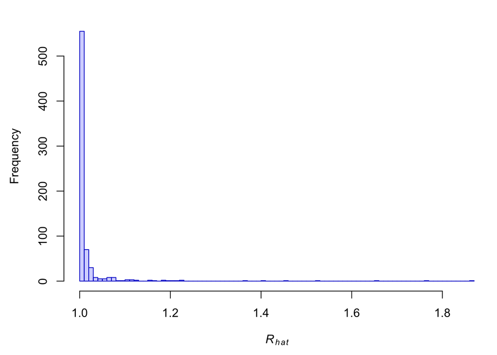

```r
mod_fit <- best_fit
## Rhat values for all parameters
rh <- mod_fit$BUGSoutput$summary[,"Rhat"]
## histogram of Rhat values for all parameters
par(mai = c(0.9,0.9,0.3,0.1))
hist(rh, breaks = seq(1,ceiling(max(rh)/0.01)*0.01,by = 0.01),main = "",
col = rgb(0,0,255,alpha = 50,maxColorValue = 255),border = "blue3",xlab = expression(italic(R[hat])))
```

```r
## Rhat values > threshold
bad_Rhat <- rh[rh>Rhat_thresh]
## prop of params with Rhat > threshold
round(length(bad_Rhat)/length(rh),3)
```

```
## [1] 0.035
```

```r
## param names
par_names <- sub("\\[.*","",names(bad_Rhat))
## number of Rhat > threshold by param name
table(par_names)
```

```
## par_names
## pi_vec    Rec
##     19      6
```

```r
## index values for offenders
idx <- as.integer(sub("(^.*\\[)([0-9]{1,3})(.*)","\\2",names(bad_Rhat)))
## data frame of offenders
(df <- data.frame(par = par_names, index = idx))
```

```
##       par index
## 1     Rec     7
## 2     Rec    25
## 3     Rec    27
## 4     Rec    30
## 5     Rec    33
## 6     Rec    34
## 7  pi_vec    18
## 8  pi_vec     8
## 9  pi_vec    14
## 10 pi_vec    35
## 11 pi_vec     2
## 12 pi_vec     3
## 13 pi_vec     4
## 14 pi_vec     6
## 15 pi_vec     7
## 16 pi_vec    14
## 17 pi_vec    20
## 18 pi_vec    23
## 19 pi_vec    25
## 20 pi_vec    26
## 21 pi_vec    27
## 22 pi_vec    30
## 23 pi_vec    33
## 24 pi_vec    34
## 25 pi_vec    36
```

The convergence statistics indicate that some of the elements in $p$ for the estimated proportions of the youngest and oldest age classes (i.e., 3 and 8, respectively) did not converge to our desired threshold. However, there is very little data to inform those parameters, so we should not be too concerned.

## Main results

Here is a table of summary statistics for some of the model parameters.

```r
tbl_smry <- mod_fit$BUGSoutput$summary[c("alpha","E_BH_a","beta","gamma"),
c("mean","sd","2.5%","50%","97.5%")]
#rownames(tbl_smry)[seq(n_cov)+2] <- colnames(dat_cvrs)
print(tbl_smry, digits = 3, quote = FALSE, justify = "right")
```

```
##            mean       sd     2.5%      50%    97.5%
## alpha  50.34495 18.25090 13.20549 52.89411 80.06839
## E_BH_a  3.90488  0.47861  2.65143  4.04368  4.46673
## beta    0.00663  0.00236  0.00166  0.00701  0.00987
## gamma  -0.07572  0.07374 -0.22240 -0.07519  0.06650
```

### Spawner-recruit relationship

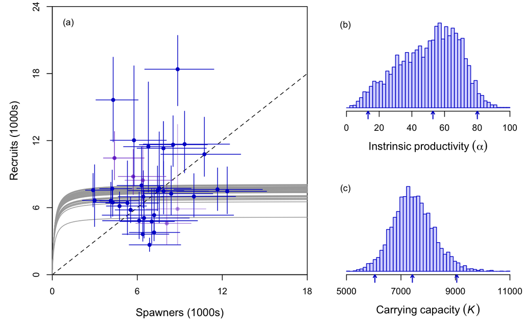

```r
layout(matrix(c(1,1,2,3),2,2),c(3,2),c(1,1))
CI_vec <- c(0.025,0.5,0.975)
offSet <- 0.06

## posterior of spawners
sDat <- apply(mod_fit$BUGSoutput$sims.list$Sp,2,quantile,CI_vec)
sDat <- sDat[,1:(n_yrs-age_min+n_fore)]
## posterior of recruits
rDat <- exp(apply(mod_fit$BUGSoutput$sims.list$tot_ln_Rec,2,quantile,CI_vec))
## median values for a & b
aa <- apply(mod_fit$BUGSoutput$sims.list$ln_BH_a,2,median)
# bb <- apply(mod_fit$BUGSoutput$sims.list$beta,2,median)
# aa <- median(mod_fit$BUGSoutput$sims.list$alpha)
bb <- median(mod_fit$BUGSoutput$sims.list$beta)

## empty plot space for spawner-recruit relationships
dd <- 3000
yM <- Re2prec(max(rDat),"ceiling",dd)
#yM <- 30000
xM <- Re2prec(max(sDat),"ceiling",dd)
par(mai = c(0.8,0.8,0.1,0.1), omi = c(0,0,0,0))
plot(sDat[2,],rDat[2,], xlim = c(0,xM), ylim = c(0,yM), pch = 16, col = "blue3", type = "n",
     xaxs = "i", yaxs = "i", ylab = "Recruits (1000s)", xlab = "Spawners (1000s)", cex.lab = 1.2,
     xaxt = "n", yaxt = "n")
axis(1, at = seq(0,xM,dd*2), labels = seq(0,xM,dd*2)/1000)
axis(2, at = seq(0,yM,dd*2), labels = seq(0,yM,dd*2)/1000)
for(i in 1:length(aa)) { lines(exp(aa[i])*seq(0,xM)/(1+bb*seq(0,xM)), col = "darkgray") }
#for(i in 1:length(aa)) { lines(aa[i]*seq(0,xM)/(1+bb*seq(0,xM)), col = "darkgray") }
# lines(aa*seq(0,xM)/(1+bb*seq(0,xM)), col = "darkgray")
abline(a = 0,b = 1,lty = "dashed")

## add S-R estimates and medians
nCB <- n_yrs-age_max
points(sDat[2,1:nCB],rDat[2,1:nCB], xlim = c(0,xM), ylim = c(0,yM), pch = 16, col = "blue3")
segments(sDat[2,1:nCB],rDat[1,1:nCB],sDat[2,1:nCB],rDat[3,1:nCB], col = "blue3")
segments(sDat[1,1:nCB],rDat[2,1:nCB],sDat[3,1:nCB],rDat[2,1:nCB], col = "blue3")
nTB <- dim(sDat)[2]
clr <- rgb(100, 0, 200, alpha = seq(200,100,length.out = age_max-age_min+n_fore), maxColorValue = 255)
segments(sDat[2,(nCB+1):nTB],rDat[1,(nCB+1):nTB],sDat[2,(nCB+1):nTB],rDat[3,(nCB+1):nTB], col = clr)
segments(sDat[1,(nCB+1):nTB],rDat[2,(nCB+1):nTB],sDat[3,(nCB+1):nTB],rDat[2,(nCB+1):nTB], col = clr)
points(sDat[2,(nCB+1):nTB],rDat[2,(nCB+1):nTB],
       xlim = c(0,xM), ylim = c(0,yM), pch = 16, col = clr)
text(x = par()$usr[1]+par()$pin[2]/par()$pin[1]*offSet*diff(par()$usr[1:2]),
     y = par()$usr[4]-offSet*diff(par()$usr[3:4]),"(a)")

## posterior for alpha
clr <- rgb(0, 0, 255, alpha = 50, maxColorValue = 255)
a_thresh <- 99
par(mai = c(0.8,0.4,0.3,0.1))
## B-H alpha
R_alpha_est <- mod_fit$BUGSoutput$sims.list$alpha
alphaCI <- quantile(R_alpha_est,c(0.025,0.5,0.975))
R_alpha_est[R_alpha_est>a_thresh] <- a_thresh
hist(R_alpha_est,freq = FALSE,xlab = "",main = "",breaks = seq(0,a_thresh+1,2),
col = clr, border = "blue3", ylab = "", cex.lab = 1.2, yaxt = "n")
aHt <- (par()$usr[4]-par()$usr[3])/12
arrows(alphaCI,par()$usr[3],alphaCI,par()$usr[3]-aHt,
code = 1,length = 0.05,xpd = NA,col = "blue3",lwd = 1.5)
mtext(expression(Instrinsic~productivity~(alpha)), 1, line = 3, cex = 1)
text(x = par()$usr[1]+par()$pin[2]/par()$pin[1]*offSet*diff(par()$usr[1:2]),
y = par()$usr[4]-offSet*diff(par()$usr[3:4]),"(b)")

## posterior for K
par(mai = c(0.8,0.4,0.3,0.1))
aa <- matrix(mod_fit$BUGSoutput$sims.array[,,"alpha"],ncol = 1)
bb <- matrix(mod_fit$BUGSoutput$sims.array[,,"beta"],ncol = 1)
R_b_est <- (aa-1)/bb
R_b_est <- R_b_est[R_b_est > 0]
R_b_CI <- quantile(R_b_est,c(0.025,0.5,0.975))
R_b_est[R_b_est>12e3] <- 12e3
brks <- seq(Re2prec(min(R_b_est),"floor",1000),
Re2prec(max(R_b_est),"ceiling",1000),
length.out = length(seq(0,a_thresh,2)))
hist(R_b_est, freq = FALSE, breaks = brks, col = clr, border = "blue3",
xlab = "", xaxt = "n", yaxt = "n",
main = "", ylab = "", cex.lab = 1.2)
axis(1, at = seq(Re2prec(min(R_b_est),"floor",1000),
Re2prec(max(R_b_est),"ceiling",1000),
2000))
aHt <- (par()$usr[4]-par()$usr[3])/12
arrows(R_b_CI,par()$usr[3],R_b_CI,par()$usr[3]-aHt,
code = 1,length = 0.05,xpd = NA,col = "blue3",lwd = 1.5)
mtext(expression(Carrying~capacity~(italic(K))), 1, line = 3, cex = 1)
text(x = par()$usr[1]+par()$pin[2]/par()$pin[1]*offSet*diff(par()$usr[1:2]),
y = par()$usr[4]-offSet*diff(par()$usr[3:4]),"(c)")
```

### Covariate effects

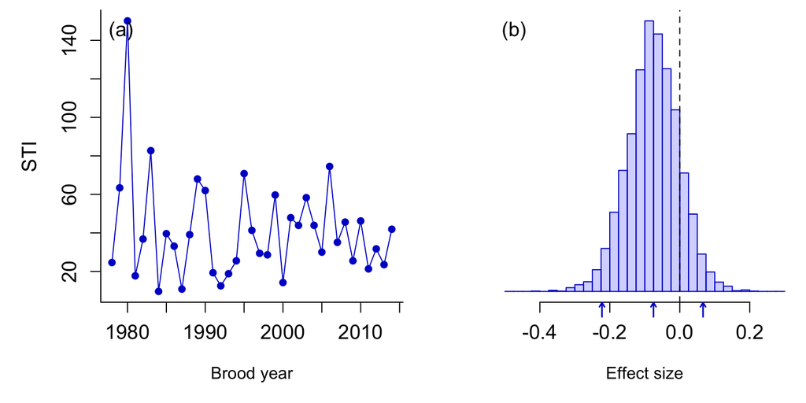

```r
clr <- rgb(0, 0, 255, alpha = 50, maxColorValue = 255)
offSet <- 0.07
c_est <- mod_fit$BUGSoutput$sims.list$gamma
par(mfrow = c(1,2), mai = c(0.9,0.9,0,0), omi = c(0.1,0.1,0.1,0.1))
ylN <- floor(min(c_est)*10)/10
ylM <- ceiling(max(c_est)*10)/10
brks <- seq(ylN,ylM,length.out = diff(c(ylN,ylM))*40+1)
# cov_names <- expression(paste("H releases (",10^3,")"))
cov_names <- tbl_LOO[best_idx,"covar"]
t_idx <- seq(yr_frst,length.out = n_yrs-age_min+n_fore)
## plot covar ts
plot(t_idx, dat_cvrs[seq(length(t_idx)),tbl_LOO[best_idx,"covar"]], xlab = "Brood year", ylab = "",
     main = "", cex.axis = 1.2, pch = 16, col = "blue3", type = "o", bty = "L")
text(x = par()$usr[1]+par()$pin[2]/par()$pin[1]*offSet*diff(par()$usr[1:2]),
     y = par()$usr[4]-offSet*diff(par()$usr[3:4]),paste0("(",letters[1],")"), cex = 1.2)
mtext(side = 2, cov_names, line = 3, cex = 1.2)
## plot covar effect
hist(c_est,
     freq = FALSE,breaks = brks,col = clr,border = "blue3",
     xlab = "Effect size", yaxt = "n", main = "", ylab = "", cex.axis = 1.2)
c_CI <- quantile(c_est,c(0.025,0.5,0.975))
aHt <- (par()$usr[4]-par()$usr[3])/20
arrows(c_CI,par()$usr[3]-0.005,c_CI,par()$usr[3]-aHt,
       code = 1,length = 0.05,xpd = NA,col = "blue3",lwd = 1.5)
abline(v = 0, lty = "dashed")
text(x = par()$usr[1]+par()$pin[2]/par()$pin[1]*offSet*diff(par()$usr[1:2]), cex = 1.2,
     y = par()$usr[4]-offSet*diff(par()$usr[3:4]),paste0("(",letters[2],")"))
```

### Total population size

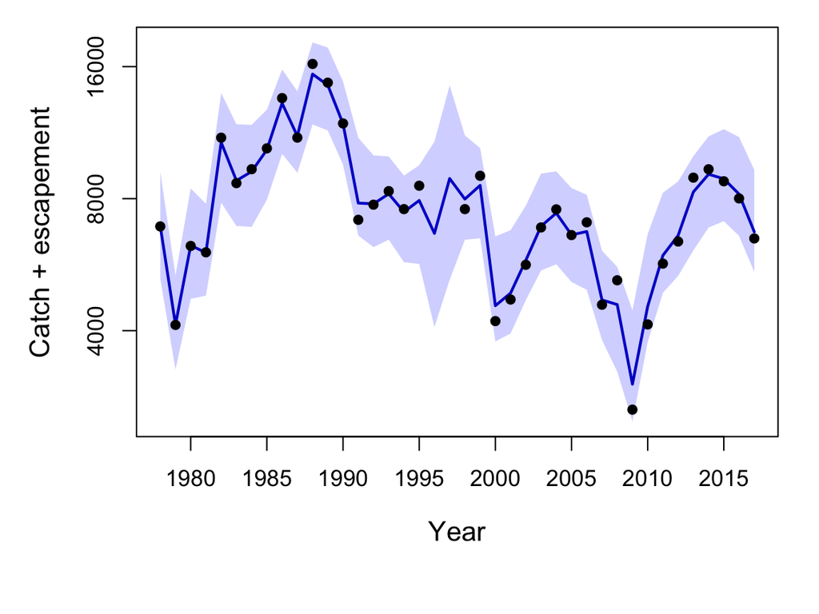

```r
pDat <- apply(mod_fit$BUGSoutput$sims.list$Sp, 2, quantile, probs = CI_vec)
pDat <- pDat + matrix(dat_harv, length(CI_vec), n_yrs+n_fore, byrow = TRUE)
t_idx_f <- seq(yr_frst, length.out = n_yrs+n_fore)
ypMin <- min(pDat)
ypMax <- max(pDat)
par(mai = c(0.8,0.8,0.1,0.1), omi = c(0.5,0.2,0.1,0.2))
plot(t_idx_f, pDat[3,], ylim = c(ypMin,ypMax), type = "n", log = "y", xaxt = "n", yaxt = "n",
xlab = "Year", ylab = "Catch + escapement", main = "", cex.lab = 1.2)
polygon(c(t_idx_f,rev(t_idx_f)),c(pDat[3,],rev(pDat[1,])), col = clr, border = NA)
lines(t_idx_f, pDat[2,], col = "blue3", lwd = 2)
points(t_idx_f, exp(ln_dat_esc)+dat_harv, pch = 16, cex = 1)
axis(1,at = seq(1980,2015,5))
axis(2,at = c(4000,8000,16000))
```

```r
data.frame(forecast = round(quantile(mod_fit$BUGSoutput$sims.list$Sp[,n_yrs+n_fore],
                                     probs = c(0.025,0.25,0.5,0.75,0.975))))
```

```
##       forecast
## 2.5%      5332
## 25%       6239
## 50%       6607
## 75%       7230
## 97.5%     9187
```

### Innovations

Here is the time series of the so-called “innovations”, which are the residuals from the process model. They give some indication of population productivity after accounting for the effects of density dependence.

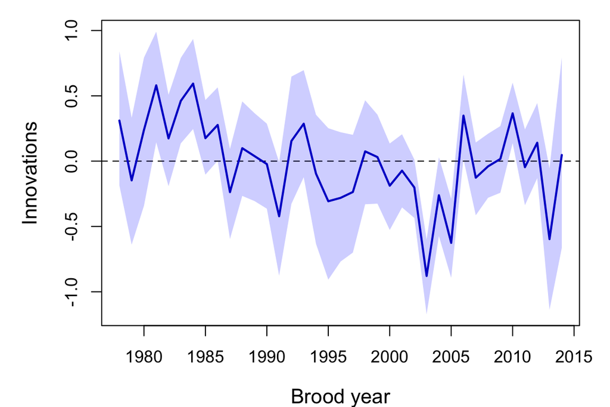

```r
t_idx_a <- seq(yr_frst, length.out = n_yrs-age_min+n_fore)
pDat <- apply(mod_fit$BUGSoutput$sims.list$res_ln_Rec,2,quantile,CI_vec)
ypMin <- min(pDat)
ypMax <- max(pDat)
par(mai = c(0.8,0.8,0.1,0.1), omi = c(0,0.2,0.1,0.2))
plot(t_idx_a,pDat[3,], ylim = c(ypMin,ypMax), type = "n", #log = "y",
xlab = "Brood year", ylab = "Innovations", main = "", cex.lab = 1.2)
abline(h = 0, lty = "dashed")
polygon(c(t_idx_a,rev(t_idx_a)),c(pDat[3,],rev(pDat[1,])), col = clr, border = NA)
lines(t_idx_a, pDat[2,], col = "blue3", lwd = 2)
```

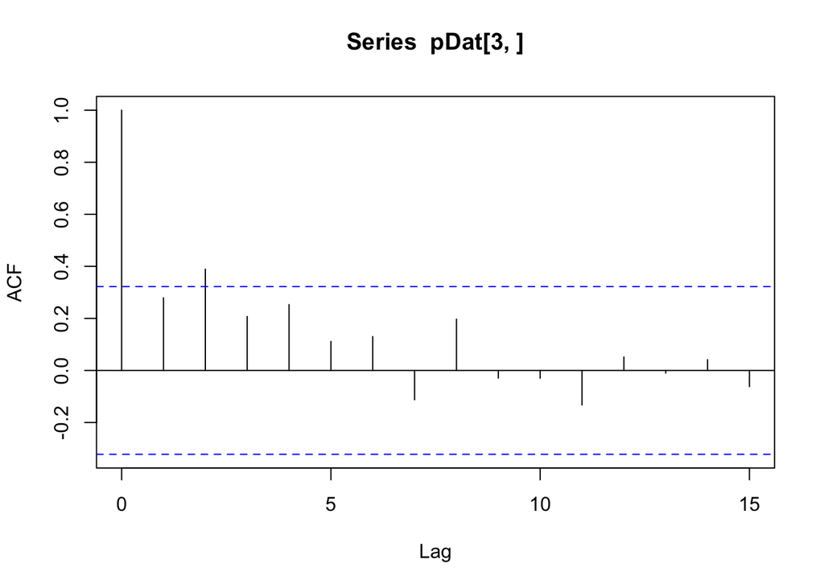

```r
acf(pDat[3,])
```